# Math 189: Multivariate Analysis of Variance I

# Comparing More Than Two Populations

- We have learned how to test if one population mean vector equals a specific vector
  $$H_0: \underline{\mu}^{(1)} = \underline{\mu}_0 \quad H_a: \underline{\mu}^{(1)} \neq \underline{\mu}_0.$$
- Also, we have learned how to test if two populations have equal mean vectors
  $$H_0: \underline{\mu}^{(1)} = \underline{\mu}^{(2)} \quad H_a: \underline{\mu}^{(1)} \neq \underline{\mu}^{(2)}.$$
- What if we want to test the equivalence of mean vectors among three or more populations?
- Suppose $\underline{\mu}^{(1)}, \ldots, \underline{\mu}^{(g)}$ are mean vectors of $g$ populations. We are interested in testing
  $$H_0: \underline{\mu}^{(1)} = \ldots = \underline{\mu}^{(g)}
  \quad H_a: \underline{\mu}^{(i)} \neq \underline{\mu}^{(j)} \; \mbox{for some} \, i \neq j.$$
- The null hypothesis assumes all mean vectors to be the same. The null hypothesis is false (alternative is true) if any two mean vectors are different.

## Example: Romano-British Pottery Data

- Romano-British Pottery shards are collected from four sites in the British Isles:
1. L: Llanedeyrn
2. C: Caldicot
3. I: Isle Thorns
4. A: Ashley Rails

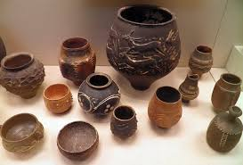

SwissFrance

- Each pottery sample was returned to the laboratory for a chemical test. In these tests the concentrations of five different chemicals were measured:
1. Al: Aluminum
2. Fe: Iron
3. Mg: Magnesium
4. Ca: Calcium
5. Na: Sodium
- Does the chemical content of the pottery depend on the site where the pottery was discovered? If yes, we can use the chemical content of a pottery sample of unknown origin to determine which site the sample came from.

## A Peek at the Data

Adopted from: Tubb, A., A. J. Parker, and G. Nickless. 1980. “The Analysis of Romano-British Pottery by Atomic Absorption Spectrophotometry”. *Archaeometry* 22: 153-71.

```r
pottery <- read.csv("C:\\Users\\neide\\Documents\\GitHub\\ma189\\Data\\RBPottery.csv")
colnames(pottery) <- c("No", "ID", "Kiln", "Al", "Fe", "Mg", "Ca", "Na", "K2O", "TiO2", "MnO", "BaO")
pot_llan <- pottery[pottery$Kiln==2,]
pot_cald <- pottery[pottery$Kiln==3,]
pot_is <- pottery[pottery$Kiln==4,]
pot_ar <- pottery[pottery$Kiln==5,]
pottery[c(23,37,39,44),4:8]
```

|  | Al | Fe | Mg | Ca | Na |
| --- | --- | --- | --- | --- | --- |
| 23 | 14.4 | 7.00 | 4.30 | 0.15 | 0.51 |
| 37 | 11.6 | 5.39 | 3.77 | 0.29 | 0.06 |
| 39 | 18.3 | 1.28 | 0.67 | 0.03 | 0.03 |
| 44 | 17.7 | 1.12 | 0.56 | 0.06 | 0.06 |

Dataset contains $26$ ancient pottery shards found at four sites in British Isles. For each of $26$ samples of pottery, the percentages of oxides of five metals are measured.

# Analysis of Variance (ANOVA)

- ANalysis Of VAriance (ANOVA) is a set of statistical tools used to analyze the differences among population means given their samples. *ANOVA* is useful for comparing (testing) three or more group means for statistical significance.
- ANOVA was developed by British statistician Ronald Fisher.
- ANOVA is conceptually similar to multiple two-sample tests, but is more conservative (fewer type I errors). It is suited to a wide range of practical problems.

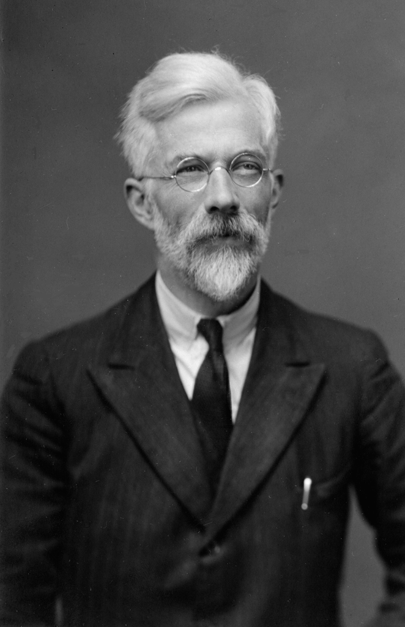

Fisher

## Univariate ANOVA

- We begin with the univariate case. Suppose we have $g$ treatments (samples). For the $k$th treatment, we observe its effects on a group of patients of size $n_k$. The dataset can be summarized in the following table.
  $$\left[ \begin{array}{ccccc} & 1 & 2 & \ldots & g \\
  1 & x_{11} & x_{12} & \ldots & x_{1g} \\
  2 & x_{21} & x_{22} & \ldots & x_{2g} \\
  \vdots & \vdots & \vdots & \ddots & \vdots \\
  n_k & x_{n_1,1} & x_{n_2,1} & \ldots & x_{n_g, g}
  \end{array} \right]$$

### Notation:

- $x_{ik}$ is $i$th observation in $k$th sample
- $n_k$ is number of observations in $k$th sample
- $N = n_1 + \ldots + n_g$ is total sample size
- $g$ is the number of treatments/populations/samples

### Assumptions for the ANOVA:

1. The data from group $k$ has common mean $\mu_k$, i.e., ${\mathbb E} [ x_{ik} ] = \mu_k$.
2. *Homoskedasticity*: the data from all groups have common variance $\sigma^2$.
3. Independence: the observations are independently sampled.
4. Normality: the data are normally distributed.

The hypothesis of interest is that all of the means are equal. Mathematically this is formulated as:
$$H_0: \ {\mu}^{(1)} = \ldots = \ {\mu}^{(g)}
\quad H_a: \ {\mu}^{(i)} \neq \ {\mu}^{(j)} \; \mbox{for some} \, i \neq j.$$
- The alternative hypothesis indicates there exists at least one pair of different group population means.

## Total Sum of Squares

- Consider the following notation:
  $$\overline{x}_k = \frac{1}{n_k} \sum_{i=1}^{n_k} x_{ik},$$
  the sample mean of the $k$th sample.
  $$\overline{x} = \frac{1}{N} \sum_{k=1}^g \sum_{i=1}^{n_k} x_{ik},$$
  the grand mean (or, the overall sample mean).
- The Analysis of Variance involves a partitioning of the total sum of squares, defined as:
  $$\mbox{SS}_{total} = \sum_{k=1}^g \sum_{i=1}^{n_k} {( x_{ik} - \overline{x} )}^2.$$
- $\mbox{SS}_{total}$ is the sum of squared differences between each observation and the grand mean, which measures variation of the data around the grand mean.
- When observations are far away from the grand mean, it tends to take a large value.
- When observations are close to the grand mean, it tends to take a small value.

## Partitioning Total Sum of Squares

- An Analysis of Variance (ANOVA) is a partitioning of the total sum of squares.
  $$\begin{align}
  \mbox{SS}_{total} & = \sum_{k=1}^g \sum_{i=1}^{n_k} {( x_{ik} - \overline{x} )}^2 \\
  & = \sum_{k=1}^g \sum_{i=1}^{n_k} {[ ( x_{ik} - \overline{x}_k ) - (\overline{x}_k - \overline{x} ) ]}^2 \\
  & = \sum_{k=1}^g \sum_{i=1}^{n_k} { ( x_{ik} - \overline{x}_k )}^2 +
  \sum_{k=1}^g n_k { (\overline{x}_k - \overline{x} ) }^2.
  \end{align}$$
- The first term is called the *error sum of squares* and measures the variation in the data about their group means. Denoted as $\mbox{SS}_{error}$.
- The second term is called the *treatment sum of squares* and involves the differences between the group means and the Grand mean. Denoted as $\mbox{SS}_{treat}$.
- Error sum of squares ($\mbox{SS}_{error}$) measures the within-group variability.
- Treatment sum of squares ($\mbox{SS}_{treat}$) measures the between-group variability.

### Intuitions

- When the null hypothesis is true, i.e.
  $$H_0: \ {\mu}^{(1)} = \ldots = \ {\mu}^{(g)}
  \quad H_a: \ {\mu}^{(i)} \neq \ {\mu}^{(j)} \; \mbox{for some} \, i \neq j,$$
  we would expect the between-group variability to be small and within-group variability to be large.
- On the other hand, when the null hypothesis is false, we would expect the between-group variability to be large and within-group variability to be small.

## A Simulated Example

- We simulate two datasets, each contains two samples (to compare).
- Here we draw the histogram for each dataset.
- Can you tell if the population means of the two samples are equal or not?

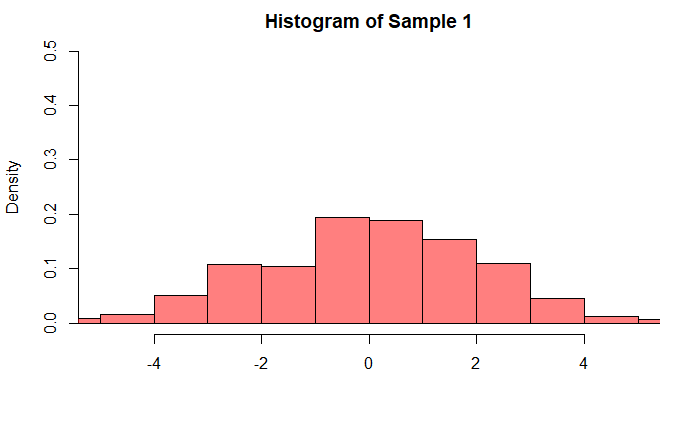

```r
# Generate simulations
n <- 500
x1 <- cbind(matrix(rnorm(n*1,-0.5,2),n,1),
            matrix(rnorm(n*1,0.5,2),n,1))
x2 <- cbind(matrix(rnorm(n*1,-2,1),n,1),
            matrix(rnorm(n*1,2,1),n,1))

# Data visualization via histograms
hist(rbind(x1[,1],x1[,2]), breaks=20, xlim=c(-5,5),ylim=c(0,0.5),freq = F,
     main="Histogram of Sample 1", xlab="", col=rgb(1,0,0,0.5))
```

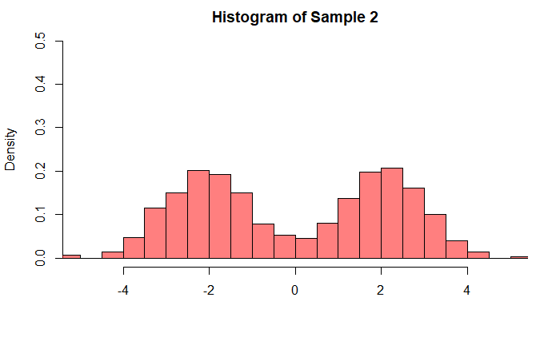

```r
hist(rbind(x2[,1],x2[,2]), breaks=20, xlim=c(-5,5),ylim=c(0,0.5),freq = F,
     main="Histogram of Sample 2", xlab="", col=rgb(1,0,0,0.5))
```

### True Data Generating Process

```r
nv <- c(n,n)
center_x1 <- x1 - matrix(colMeans(x1), nr=dim(x1)[1], nc=dim(x1)[2], byrow=TRUE)
center_x2 <- x2 - matrix(colMeans(x2), nr=dim(x2)[1], nc=dim(x2)[2], byrow=TRUE)
ESS1 <- sum(center_x1^2)
TSS1 <- nv%*%(colMeans(x1)-mean(x1))^2
ESS2 <- sum(center_x2^2)
TSS2 <- nv%*%(colMeans(x2)-mean(x2))^2
```

Both datasets have un-equal population means. Why is this easier to discern in the second dataset?

### Distinguish with Colors

```r
# Data visualization via histograms
hist(x1[,1], breaks=20, xlim=c(-5,5),ylim=c(0,0.5),freq = F,
     main="Histogram of Sample 1", xlab="", col=rgb(1,0,0,0.5))
hist(x1[,2], breaks=20, col=rgb(0,0,1,0.5),freq = F, add=T )
```

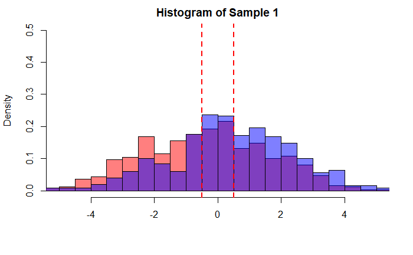

```r
abline(v = -0.5, col="red", lwd=2, lty=2)
abline(v = 0.5, col="red", lwd=2, lty=2)
```

```r
hist(x2[,1], breaks=20, xlim=c(-5,5),ylim=c(0,0.5),freq = F,
     main="Histogram of Sample 2", xlab="", col=rgb(1,0,0,0.5))
hist(x2[,2], breaks=20, col=rgb(0,0,1,0.5),freq = F, add=T)
```

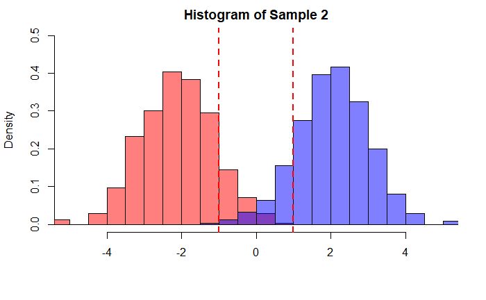

```r
abline(v = -1, col="red", lwd=2, lty=2)
abline(v = 1, col="red", lwd=2, lty=2)
```

## Design of Test Statistic

- Motivated by this toy example, we should reject the null hypothesis when the Treatment Sum of Squares ($\mbox{SS}_{treat}$) is large. Given the same level of total sum of squares, a large $\mbox{SS}_{treat}$ will result $\mbox{SS}_{error}$.
- We want to find a test statistic which is proportional to $\mbox{SS}_{treat}$ and inversely proportional to $\mbox{SS}_{error}$.
- A naive approach is to use the ratio
  $$\mbox{SS}_{treat} / \mbox{SS}_{error}.$$

### Calculation for Simulated Datasets:

#### Solution:

1. We rescale the sum of squares by dividing their degrees of freedom.
2. Change from ratio between sum of squares to the ratio between mean of squares.

## Degrees of Freedom (DOF)

- We check the degrees of freedom of these sum of squares
- Error sum of squares
  $$\mbox{SS}_{error} = \sum_{k=1}^g \sum_{i=1}^{n_k} { ( x_{ik} - \overline{x}_k )}^2 \sim \chi^2_{N-g}.$$
- Treatment sum of squares
  $$\mbox{SS}_{treat} = \sum_{k=1}^g n_k { (\overline{x}_k - \overline{x} ) }^2 \sim \chi^2_{g-1}.$$
- Total sum of squares
  $$\mbox{SS}_{total} = \sum_{k=1}^g \sum_{i=1}^{n_k} {( x_{ik} - \overline{x} )}^2 \sim \chi^2_{N-1}.$$
- Therefore, the three degrees of freedom satisfy
  $$\mbox{DF}_{total} = \mbox{DF}_{treat} + \mbox{DF}_{error}.$$

## An F-Statistic as the Ratio of Means of Squares

- Error mean of squares
  $$\mbox{MS}_{error} = \frac{1}{N-g} \mbox{SS}_{error} =
  \frac{1}{N-g} \sum_{k=1}^g \sum_{i=1}^{n_k} { ( x_{ik} - \overline{x}_k )}^2.$$
- Treatment mean of squares
  $$\mbox{MS}_{treat} = \frac{1}{g-1} \mbox{SS}_{treat} =
  \frac{1}{g-1} \sum_{k=1}^g n_k { (\overline{x}_k - \overline{x} ) }^2.$$
- Then we can define an $F$-statistic as the ratio between $\mbox{MS}_{treat}$ and $\mbox{MS}_{error}$:
  $$F = \frac{ \mbox{MS}_{treat} }{ \mbox{MS}_{error} } \sim \mathcal{F}_{g-1,N-g}.$$
- At significance level $\alpha$ we reject the null hypothesis $H_0$ if
  $$F > \mathcal{F}_{g-1,N-g,\alpha}.$$

## Example: Romano-British Pottery Data

Question: Which chemical element varies significantly across sites? - As a naive approach to assess the significance of individual variables (chemical elements), we consider the following univariate multisample testing:
$$H_0^{(j)}: \mu_{1j} = \mu_{2j} = \ldots = \mu_{gj}$$
for variables $1 \leq j \leq m$.

- For the $j$th chemical, we apply a univariate ANOVA and calculate an $F$-statistic $F^{(j)}$, for $1 \leq j \leq m$.
- For a significance level $\alpha$, we reject the null hypothesis $H_0^{(j)}$ if
  $$F^{(j)} > \mathcal{F}_{g-1,N-g,\alpha}.$$
- Sounds like a good plan? What about FWER?
- To control the type I errors among multiple testing, we can utilize Bonferroni correction.
- To control the FWER at level $\alpha$, we adjust the significance level for each individual test to $\alpha/m$ instead of $\alpha$.
- At a significance level $\alpha$, we reject the null hypothesis $H_0^{(j)}$ if
  $$F^{(j)} > \mathcal{F}_{g-1,N-g,\alpha/m}.$$
- Other type I error control methods can also be applied depending on your goals.
- The Pottery data contains $m=5$ variables, $g=4$ groups, and a total number of $N=26$ observations. For an $\alpha = 0.05$ level test, we reject the $j$th null hypothesis $H_0^{(j)}$ if
  $$F^{(j)} > \mathcal{F}_{3,22,.01},$$
  which equals 4.8166058.

```r
pot <- NULL
pot <- rbind(pot,pot_llan)
pot <- rbind(pot,pot_cald)
pot <- rbind(pot,pot_is)
pot <- rbind(pot,pot_ar)

x <- pot$Al
n2 <- length(x[pot$Kiln == 2])
n3 <- length(x[pot$Kiln == 3])
n4 <- length(x[pot$Kiln == 4])
n5 <- length(x[pot$Kiln == 5])
N <- n2+n3+n4+n5
m2 <- mean(x[pot$Kiln == 2])
m3 <- mean(x[pot$Kiln == 3])
m4 <- mean(x[pot$Kiln == 4])
m5 <- mean(x[pot$Kiln == 5])
mg <- mean(x)
ESS1 <- sum((x[pot$Kiln == 2] - m2)^2) + sum((x[pot$Kiln == 3] - m3)^2) +
  sum((x[pot$Kiln == 4] - m4)^2) + sum((x[pot$Kiln == 5] - m5)^2)
TSS1 <- n2*(m2-mg)^2 + n3*(m3-mg)^2 + n4*(m4-mg)^2 + n5*(m5-mg)^2
F1 <- TSS1/ESS1 * (N-4)/(4-1)

x <- pot$Fe
n2 <- length(x[pot$Kiln == 2])
n3 <- length(x[pot$Kiln == 3])
n4 <- length(x[pot$Kiln == 4])
n5 <- length(x[pot$Kiln == 5])
N <- n2+n3+n4+n5
m2 <- mean(x[pot$Kiln == 2])
m3 <- mean(x[pot$Kiln == 3])
m4 <- mean(x[pot$Kiln == 4])
m5 <- mean(x[pot$Kiln == 5])
mg <- mean(x)
ESS2 <- sum((x[pot$Kiln == 2] - m2)^2) + sum((x[pot$Kiln == 3] - m3)^2) +
  sum((x[pot$Kiln == 4] - m4)^2) + sum((x[pot$Kiln == 5] - m5)^2)
TSS2 <- n2*(m2-mg)^2 + n3*(m3-mg)^2 + n4*(m4-mg)^2 + n5*(m5-mg)^2
F2 <- TSS2/ESS2 * (N-4)/(4-1)

x <- pot$Mg
n2 <- length(x[pot$Kiln == 2])
n3 <- length(x[pot$Kiln == 3])
n4 <- length(x[pot$Kiln == 4])
n5 <- length(x[pot$Kiln == 5])
N <- n2+n3+n4+n5
m2 <- mean(x[pot$Kiln == 2])
m3 <- mean(x[pot$Kiln == 3])
m4 <- mean(x[pot$Kiln == 4])
m5 <- mean(x[pot$Kiln == 5])
mg <- mean(x)
ESS3 <- sum((x[pot$Kiln == 2] - m2)^2) + sum((x[pot$Kiln == 3] - m3)^2) +
  sum((x[pot$Kiln == 4] - m4)^2) + sum((x[pot$Kiln == 5] - m5)^2)
TSS3 <- n2*(m2-mg)^2 + n3*(m3-mg)^2 + n4*(m4-mg)^2 + n5*(m5-mg)^2
F3 <- TSS3/ESS3 * (N-4)/(4-1)

x <- pot$Ca
n2 <- length(x[pot$Kiln == 2])
n3 <- length(x[pot$Kiln == 3])
n4 <- length(x[pot$Kiln == 4])
n5 <- length(x[pot$Kiln == 5])
N <- n2+n3+n4+n5
m2 <- mean(x[pot$Kiln == 2])
m3 <- mean(x[pot$Kiln == 3])
m4 <- mean(x[pot$Kiln == 4])
m5 <- mean(x[pot$Kiln == 5])
mg <- mean(x)
ESS4 <- sum((x[pot$Kiln == 2] - m2)^2) + sum((x[pot$Kiln == 3] - m3)^2) +
  sum((x[pot$Kiln == 4] - m4)^2) + sum((x[pot$Kiln == 5] - m5)^2)
TSS4 <- n2*(m2-mg)^2 + n3*(m3-mg)^2 + n4*(m4-mg)^2 + n5*(m5-mg)^2
F4 <- TSS4/ESS4 * (N-4)/(4-1)

x <- pot$Na
n2 <- length(x[pot$Kiln == 2])
n3 <- length(x[pot$Kiln == 3])
n4 <- length(x[pot$Kiln == 4])
n5 <- length(x[pot$Kiln == 5])
N <- n2+n3+n4+n5
m2 <- mean(x[pot$Kiln == 2])
m3 <- mean(x[pot$Kiln == 3])
m4 <- mean(x[pot$Kiln == 4])
m5 <- mean(x[pot$Kiln == 5])
mg <- mean(x)
ESS5 <- sum((x[pot$Kiln == 2] - m2)^2) + sum((x[pot$Kiln == 3] - m3)^2) +
  sum((x[pot$Kiln == 4] - m4)^2) + sum((x[pot$Kiln == 5] - m5)^2)
TSS5 <- n2*(m2-mg)^2 + n3*(m3-mg)^2 + n4*(m4-mg)^2 + n5*(m5-mg)^2
F5 <- TSS5/ESS5 * (N-4)/(4-1)
```

- The testing results are listed below. As all $F$ statistics 26.6692593, 89.8827246, 49.1200876, 29.1566991, 9.502604 exceed the critical value 4.8166058, we reject all the null hypotheses.

**Conclusion**: All chemical elements differ significantly among the sites. Each element is significantly different between at least one pair of sites.